# Bay Wheels System Data Exploratory Analysis

## Contents

- Introduction
- Preliminary Wrangling
- Dataset Overview
- Univariate Exploration
- Bivariate Exploration
- Multivariate Exploration
- References

## Introduction

Bay Wheels is a public bicycle sharing system in the San Francisco Bay Area, California. Motivate, in collaboration with the Metropolitan Transportation Commission and the Bay Area Air Quality Management District, operates it. Bay Wheels is the first regional and large-scale bicycle sharing scheme in California and the United States' West Coast. In August of 2013, the Bay Area Bike Share programme was launched. The Bay Wheels system had over 2,600 bicycles in 262 stations across San Francisco, the East Bay, and San Jose as of January 2018.

In a collaboration with Ford Motor Company, the system was formally re-launched as Ford GoBike in June 2017. In June 2019, the system was renamed to Bay Wheels after Motivate's acquisition by Lyft. The system is planned to grow to 7,000 bicycles in San Francisco, Oakland, Berkeley, Emeryville, and San Jose, with 540 stations.

## Preliminary Wrangling

```python
# import all packages and set plots to be embedded inline
import numpy as np
import pandas as pd
import matplotlib.pyplot as plt
import seaborn as sns
import os
import glob
np.random.seed(2021)
from numpy import median
import warnings
warnings.filterwarnings('ignore')
%matplotlib inline
```

```python
# load in the dataset into a pandas dataframe, view top 5 entries
df = pd.read_csv('201902-fordgobike-tripdata.csv')
df.head()
```

|  | duration_sec | start_time | end_time | start_station_id | start_station_name | start_station_latitude | start_station_longitude | end_station_id | end_station_name | end_station_latitude | end_station_longitude | bike_id | user_type | member_birth_year | member_gender | bike_share_for_all_trip |
| --- | --- | --- | --- | --- | --- | --- | --- | --- | --- | --- | --- | --- | --- | --- | --- | --- |
| 0 | 52185 | 2019-02-28 17:32:10.1450 | 2019-03-01 08:01:55.9750 | 21.0 | Montgomery St BART Station (Market St at 2nd St) | 37.789625 | -122.400811 | 13.0 | Commercial St at Montgomery St | 37.794231 | -122.402923 | 4902 | Customer | 1984.0 | Male | No |
| 1 | 42521 | 2019-02-28 18:53:21.7890 | 2019-03-01 06:42:03.0560 | 23.0 | The Embarcadero at Steuart St | 37.791464 | -122.391034 | 81.0 | Berry St at 4th St | 37.775880 | -122.393170 | 2535 | Customer | NaN | NaN | No |
| 2 | 61854 | 2019-02-28 12:13:13.2180 | 2019-03-01 05:24:08.1460 | 86.0 | Market St at Dolores St | 37.769305 | -122.426826 | 3.0 | Powell St BART Station (Market St at 4th St) | 37.786375 | -122.404904 | 5905 | Customer | 1972.0 | Male | No |
| 3 | 36490 | 2019-02-28 17:54:26.0100 | 2019-03-01 04:02:36.8420 | 375.0 | Grove St at Masonic Ave | 37.774836 | -122.446546 | 70.0 | Central Ave at Fell St | 37.773311 | -122.444293 | 6638 | Subscriber | 1989.0 | Other | No |
| 4 | 1585 | 2019-02-28 23:54:18.5490 | 2019-03-01 00:20:44.0740 | 7.0 | Frank H Ogawa Plaza | 37.804562 | -122.271738 | 222.0 | 10th Ave at E 15th St | 37.792714 | -122.248780 | 4898 | Subscriber | 1974.0 | Male | Yes |

```python
# high-level overview of dimensions (shape) and datatypes of the dataset
print(df.shape)
print(df.dtypes)
```

```
(183412, 16)
duration_sec                 int64
start_time                  object
end_time                    object
start_station_id           float64
start_station_name          object
start_station_latitude     float64
start_station_longitude    float64
end_station_id             float64
end_station_name            object
end_station_latitude       float64
end_station_longitude      float64
bike_id                      int64
user_type                   object
member_birth_year          float64
member_gender               object
bike_share_for_all_trip     object
dtype: object
```

```python
# Checking for missing values
df.isnull().sum()
```

```
duration_sec                  0
start_time                    0
end_time                      0
start_station_id            197
start_station_name          197
start_station_latitude        0
start_station_longitude       0
end_station_id              197
end_station_name            197
end_station_latitude          0
end_station_longitude         0
bike_id                       0
user_type                     0
member_birth_year          8265
member_gender              8265
bike_share_for_all_trip       0
dtype: int64
```

```python
# Checking for duplicate values
sum(df.duplicated())
```

```
0
```

```python
# No of unique values in each column
df.nunique()
```

```
duration_sec                 4752
start_time                 183401
end_time                   183397
start_station_id              329
start_station_name            329
start_station_latitude        334
start_station_longitude       335
end_station_id                329
end_station_name              329
end_station_latitude          335
end_station_longitude         335
bike_id                      4646
user_type                       2
member_birth_year              75
member_gender                   3
bike_share_for_all_trip         2
dtype: int64
```

### Identified Wrangling tasks

1. Dealing with missing values
2. Start time and end time should be datetime, ids and birth year should be object
3. User type, gender, bike share for all trip should be categorical data type
4. Extract hour, day from start time
5. Extract age from birth year

**Missing values**

Since we can not retrieve the 197 missing records of station id, station name and 8265 missing records of member birth year & gender and these missing values are statistically insignificant (less than 5% ) compared to the large sample size of 183412 records. Hence, we can remove them from the dataset.

```python
df = df[(df['start_station_id'].isnull() == False) & (df['start_station_name'].isnull() == False) \
   & (df['member_birth_year'].isnull() == False) & (df['member_gender'].isnull() == False)]
```

```python
df.isnull().sum()
```

```
duration_sec               0
start_time                 0
end_time                   0
start_station_id           0
start_station_name         0
start_station_latitude     0
start_station_longitude    0
end_station_id             0
end_station_name           0
end_station_latitude       0
end_station_longitude      0
bike_id                    0
user_type                  0
member_birth_year          0
member_gender              0
bike_share_for_all_trip    0
dtype: int64
```

**Dealing with invalid data types**

```python
df.info()
```

```
<class 'pandas.core.frame.DataFrame'>
Int64Index: 174952 entries, 0 to 183411
Data columns (total 16 columns):
 #   Column                   Non-Null Count   Dtype
---  ------                   --------------   -----
 0   duration_sec             174952 non-null  int64
 1   start_time               174952 non-null  object
 2   end_time                 174952 non-null  object
 3   start_station_id         174952 non-null  float64
 4   start_station_name       174952 non-null  object
 5   start_station_latitude   174952 non-null  float64
 6   start_station_longitude  174952 non-null  float64
 7   end_station_id           174952 non-null  float64
 8   end_station_name         174952 non-null  object
 9   end_station_latitude     174952 non-null  float64
 10  end_station_longitude    174952 non-null  float64
 11  bike_id                  174952 non-null  int64
 12  user_type                174952 non-null  object
 13  member_birth_year        174952 non-null  float64
 14  member_gender            174952 non-null  object
 15  bike_share_for_all_trip  174952 non-null  object
dtypes: float64(7), int64(2), object(7)
memory usage: 22.7+ MB
```

```python
df.start_station_id = df.start_station_id.astype(str)
df.end_station_id = df.end_station_id.astype(str)
df.bike_id = df.bike_id.astype(str)
```

```python
df.user_type.unique()
```

```
array(['Customer', 'Subscriber'], dtype=object)
```

```python
df.user_type = df.user_type.astype('category')
```

```python
df.member_gender.unique()
```

```
array(['Male', 'Other', 'Female'], dtype=object)
```

```python
df.member_gender = df.member_gender.astype('category')
```

```python
df.bike_share_for_all_trip.unique()
```

```
array(['No', 'Yes'], dtype=object)
```

```python
df.bike_share_for_all_trip = df.bike_share_for_all_trip.astype('category')
```

```python
df['start_time'] = pd.to_datetime(df['start_time'])
df['end_time'] = pd.to_datetime(df['end_time'])
```

```python
df['hour'] = df.start_time.dt.hour.astype(str)
df['dayofweek'] = df.start_time.dt.strftime('%a')
```

```python
df['member_age'] = 2021 - df['member_birth_year'].astype(int)
```

```python
df.head()
```

|  | duration_sec | start_time | end_time | start_station_id | start_station_name | start_station_latitude | start_station_longitude | end_station_id | end_station_name | end_station_latitude | end_station_longitude | bike_id | user_type | member_birth_year | member_gender | bike_share_for_all_trip | hour | dayofweek | member_age |
| --- | --- | --- | --- | --- | --- | --- | --- | --- | --- | --- | --- | --- | --- | --- | --- | --- | --- | --- | --- |
| 0 | 52185 | 2019-02-28 17:32:10.145 | 2019-03-01 08:01:55.975 | 21.0 | Montgomery St BART Station (Market St at 2nd St) | 37.789625 | -122.400811 | 13.0 | Commercial St at Montgomery St | 37.794231 | -122.402923 | 4902 | Customer | 1984.0 | Male | No | 17 | Thu | 37 |
| 2 | 61854 | 2019-02-28 12:13:13.218 | 2019-03-01 05:24:08.146 | 86.0 | Market St at Dolores St | 37.769305 | -122.426826 | 3.0 | Powell St BART Station (Market St at 4th St) | 37.786375 | -122.404904 | 5905 | Customer | 1972.0 | Male | No | 12 | Thu | 49 |
| 3 | 36490 | 2019-02-28 17:54:26.010 | 2019-03-01 04:02:36.842 | 375.0 | Grove St at Masonic Ave | 37.774836 | -122.446546 | 70.0 | Central Ave at Fell St | 37.773311 | -122.444293 | 6638 | Subscriber | 1989.0 | Other | No | 17 | Thu | 32 |
| 4 | 1585 | 2019-02-28 23:54:18.549 | 2019-03-01 00:20:44.074 | 7.0 | Frank H Ogawa Plaza | 37.804562 | -122.271738 | 222.0 | 10th Ave at E 15th St | 37.792714 | -122.248780 | 4898 | Subscriber | 1974.0 | Male | Yes | 23 | Thu | 47 |
| 5 | 1793 | 2019-02-28 23:49:58.632 | 2019-03-01 00:19:51.760 | 93.0 | 4th St at Mission Bay Blvd S | 37.770407 | -122.391198 | 323.0 | Broadway at Kearny | 37.798014 | -122.405950 | 5200 | Subscriber | 1959.0 | Male | No | 23 | Thu | 62 |

```python
df.dayofweek.unique()
```

```
array(['Thu', 'Wed', 'Tue', 'Mon', 'Sun', 'Sat', 'Fri'], dtype=object)
```

```python
# Convert the "day" column from a plain object type into an ordered categorical type
days = ['Mon', 'Tue', 'Wed', 'Thu', 'Fri', 'Sat', 'Sun']
day_type = pd.api.types.CategoricalDtype(ordered = True, categories = days)
df.dayofweek = df.dayofweek.astype(day_type)
```

```python
df.dayofweek.unique()
```

```
['Thu', 'Wed', 'Tue', 'Mon', 'Sun', 'Sat', 'Fri']
Categories (7, object): ['Mon' < 'Tue' < 'Wed' < 'Thu' < 'Fri' < 'Sat' < 'Sun']
```

```python
df.hour.unique()
```

```
array(['17', '12', '23', '22', '21', '18', '20', '19', '10', '15', '16',
       '9', '11', '0', '13', '14', '8', '7', '5', '6', '4', '3', '2', '1'],
      dtype=object)
```

```python
# Convert the "hour" column from a plain object type into an ordered categorical type
hours = ['0','1','2','3','4','5','6','7','8','9','10','11','12','13','14','15','16','17','18','19','20','21','22','23']
hour_type = pd.api.types.CategoricalDtype(ordered = True, categories = hours)
df.hour = df.hour.astype(hour_type)
```

```python
df.hour.unique()
```

```
['17', '12', '23', '22', '21', ..., '6', '4', '3', '2', '1']
Length: 24
Categories (24, object): ['0' < '1' < '2' < '3' ... '20' < '21' < '22' < '23']
```

```python
df.columns
```

```
Index(['duration_sec', 'start_time', 'end_time', 'start_station_id',
       'start_station_name', 'start_station_latitude',
       'start_station_longitude', 'end_station_id', 'end_station_name',
       'end_station_latitude', 'end_station_longitude', 'bike_id', 'user_type',
       'member_birth_year', 'member_gender', 'bike_share_for_all_trip', 'hour',
       'dayofweek', 'member_age'],
      dtype='object')
```

**Removing unnecessary columns**

As all the data is of Feb 2019, we do not need whole timestamp including year and month too, we can just focus on bike trips taken in terms of time of day (hour), day of the week (day). Therefore, I am removing start_time column as I have extracted hour and day of week information from the timestamp and also member_birth_year as both member_age and member_birth_year represent the same information.

```python
df.drop(['start_time', 'member_birth_year'], axis=1, inplace=True)
```

```python
df.columns
```

```
Index(['duration_sec', 'end_time', 'start_station_id', 'start_station_name',
       'start_station_latitude', 'start_station_longitude', 'end_station_id',
       'end_station_name', 'end_station_latitude', 'end_station_longitude',
       'bike_id', 'user_type', 'member_gender', 'bike_share_for_all_trip',
       'hour', 'dayofweek', 'member_age'],
      dtype='object')
```

```python
# Final dimensions after preliminary wrangling
df.shape
```

```
(174952, 17)
```

```python
df.dtypes
```

```
duration_sec                        int64
end_time                   datetime64[ns]
start_station_id                   object
start_station_name                 object
start_station_latitude            float64
start_station_longitude           float64
end_station_id                     object
end_station_name                   object
end_station_latitude              float64
end_station_longitude             float64
bike_id                            object
user_type                        category
member_gender                    category
bike_share_for_all_trip          category
hour                             category
dayofweek                        category
member_age                          int32
dtype: object
```

```python
# saving the cleaned file to csv format for later use
df.to_csv('201902-fordgobike-tripdata-clean.csv', index=False)
```

## Dataset Overview

### What is the structure of your dataset?

The dataset with 17 features has 174,952 bike trips that happened in 2019 in the San Francisco Bay Area. The dataset contained features about:

- trip duration: `duration_sec`, `end_time`
- station info: `start_station_id`, `start_station_name`, `start_station_latitude`, `start_station_longitude`, `end_station_id`, `end_station_name`, `end_station_latitude`, `end_station_longitude`
- member info (anonymized): `bike_id`, `user_type`, `member_gender`, `bike_share_for_all_trip`

Derived features/variables to assist exploration and analysis:

- trip start time info: `hour`, `dayofweek`
- member: `member_age`

### What is/are the main feature(s) of interest in your dataset?

I'm most interested in exploring the bike trips' duration and rental events occurrance patterns in terms of time of day, day of the week, along with how these relate to the riders' characteristics, i.e. their user type, gender, age, etc. to get a sense of what and how people are using the bike sharing service for. Sample questions to answer:

1. When are most trips taken in terms of time of day, day of the week?
2. How long does the average trip take?
3. Does the above depend on if a user is a subscriber or customer?

### What features in the dataset do you think will help support your investigation into your feature(s) of interest?

Each trip's start time (hour of day and day of week) and duration information will help understanding how long a trip usually takes and when. The member information like user type, gender and age will help us in finding out the main target customer groups, use the different groups for summarizing bike usage data to see if there is any special pattern associated with a specific group of riders.

## Univariate Exploration

### Duration

```python
# converting duration into minutes for easy interpretation
df['duration_min'] = df['duration_sec']/60
```

```python
df.duration_min.describe()
```

```
count    174952.000000
mean         11.733379
std          27.370082
min           1.016667
25%           5.383333
50%           8.500000
75%          13.150000
max        1409.133333
Name: duration_min, dtype: float64
```

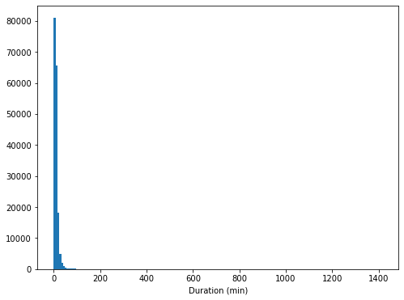

```python
binsize=8
bin_edges=np.arange(0, df.duration_min.max()+binsize, binsize)
plt.figure(figsize=[8,6])
plt.hist(data=df, x='duration_min', bins=bin_edges)
plt.xlabel('Duration (min)')
plt.show()
```

It seems that the distribution of duration is highly skewed to the right. It is a strong positively skewed distribution. Hence, we will plot it on a log scale.

```python
np.log10(df.duration_min).describe()
```

```
count    174952.000000
mean          0.929673
std           0.305190
min           0.007179
25%           0.731051
50%           0.929419
75%           1.118926
max           3.148952
Name: duration_min, dtype: float64
```

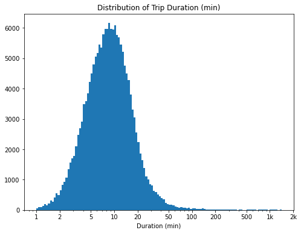

```python
log_binsize=0.025
bin_edges=10 ** np.arange(0, np.log10(df.duration_min.max())+log_binsize, log_binsize)
plt.figure(figsize=[8,6])
plt.hist(data=df, x='duration_min', bins=bin_edges)
plt.xscale('log')
plt.xticks([1,2,5,10,20,50,100,200,500,1000,2000],[1,2,5,10,20,50,100,200,500,'1k','2k'])
plt.xlabel('Duration (min)')
plt.title('Distribution of Trip Duration (min)')
plt.show()
```

The distribution is sill positively skewed with quite a few large duration minutes at the end suggesting some strong outliers on the right. Based on the histogram, we are chooosing 100 minutes as the upper bound to analyse the pattern by focusing on the most common trips.

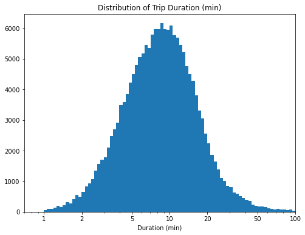

```python
log_binsize=0.025
bin_edges=10 ** np.arange(0, np.log10(df.duration_min.max())+log_binsize, log_binsize)
plt.figure(figsize=[8,6])
plt.hist(data=df, x='duration_min', bins=bin_edges)
plt.xscale('log')
plt.xticks([1,2,5,10,20,50,100,200,500,1000,2000],[1,2,5,10,20,50,100,200,500,'1k','2k'])
plt.xlabel('Duration (min)')
plt.xlim([0,100])
plt.title('Distribution of Trip Duration (min)')
plt.show()
```

```python
df.duration_min.quantile(0.95)
```

```
25.516666666666666
```

**`Observation:`** It is evident that log scaling and setting 100 minutes as the upper bound proves to be illuminating; the distribution has surprisingly become approximate to a normal distribution. Moroever, approx. 95% of the trips have duration around 25 minutes implicating that on average, the trips are of short duration.

### Member Age

```python
df.member_age.describe()
```

```
count    174952.000000
mean         36.196865
std          10.118731
min          20.000000
25%          29.000000
50%          34.000000
75%          41.000000
max         143.000000
Name: member_age, dtype: float64
```

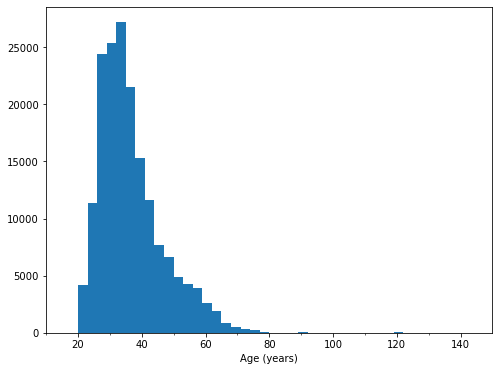

```python
binsize=3
bin_edges=np.arange(20, df.member_age.max()+binsize, binsize)
plt.figure(figsize=[8,6])
plt.hist(data=df, x='member_age', bins=bin_edges)
plt.xlabel('Age (years)')
plt.xlim([10,150])
plt.gca().set_xticks(np.arange(10, 150, 10), minor=True)
plt.show();
```

The distribution is positively skewed with some outliers at the end but instead of log scaling, we will first just try to limit the range to check if we can find any pattern. Based on the histogram, we are chooosing 70 years as the upper bound to analyse the pattern by focusing on the most common trips.

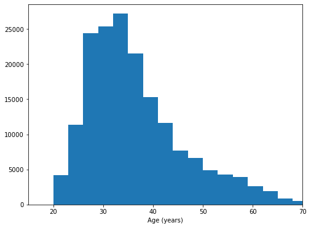

```python
binsize=3
bin_edges=np.arange(20, df.member_age.max()+binsize, binsize)
plt.figure(figsize=[8,6])
plt.hist(data=df, x='member_age', bins=bin_edges)
plt.xlabel('Age (years)')
plt.xlim([15,70])
plt.show()
```

**`Observation:`** After setting 70 years as the upper bound, the trend is clearly visible, with age still following a positively skewed distribution having more than two thirds of the trips have customers or subscribers having age 25-40 years implicating that majority of the users are middle aged adults.

**Dealing with age and duration outliers based on histogram plots**

```python
outliers = ((df.duration_min>100) | (df.member_age>70))
print(outliers.sum())
```

```
1551
```

As we can see the total number of outliers are large i.e. 1551 making it very hard to investigate each one of them for deciding if they need to be filtered out of the data. However, this number is statistically insignificant (less than 5%) as compared to the total sample size of approx. 175,000 records. Therefore, filtering out duration and age outliers from the dataset based on the histogram plots.

```python
df = df[-outliers]
```

```python
# Final dimensions after removing outliers
df.shape
```

```
(173401, 18)
```

### Categorical features (hour, day of week, user type, gender & bike share for all trip)

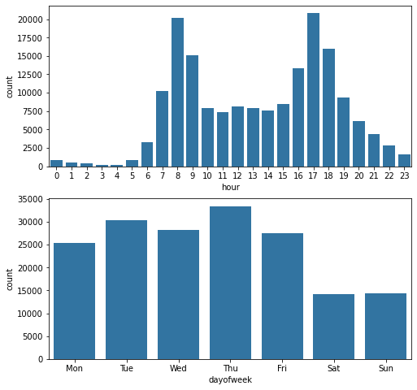

```python
# lets plot hour of the day and day of the week together to get an idea of each categorical ordinal variable's distribution.

fig, ax = plt.subplots(nrows=2, figsize = [8,8])
default_color = sns.color_palette()[0]
sns.countplot(data = df, x = 'hour', color=default_color, ax=ax[0])
sns.countplot(data = df, x = 'dayofweek', color=default_color, ax=ax[1])
plt.show()
```

**`Observation:`**

1. *Time of day:* It is evident from the first plot that the peaks are observed in mornings at 8AM & 9AM and evenings at 4PM, 5PM & 6PM implicating that majority of the trips are taken before and after the usual office hours. Moreover, the trips taken in between the usual office hours i.e. 10AM - 3PM are constant. Additionaly, the trips have declined substantially after 6PM and a gradual decreasing pattern is observed afterwards till 11PM and thereafter insignificant number of trips have taken place till 5AM with number of trips increasing substantially from 6AM.
2. *Day of week:* As majority of the trips were taken before and after the usual office hours, it is no surprise that majority of the trips have taken place at weekdays (Mon-Fri) as compared to weekends (Sat-Sun) and this trend is clearly visible in the second plot. Although, the difference between trips taken in weekdays i.e. Mon, Tue, Wed and Fri is not substantial, however, Thurs has the highest number of trips having the highest peak.

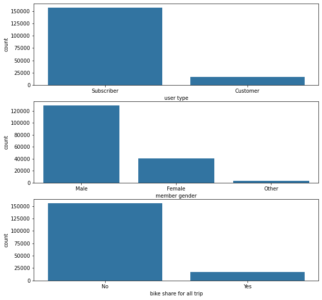

```python
# let's plot user type, member gender and bike share for all trip together to get an idea of each categorical nominal
# variable's distribution.

fig, ax = plt.subplots(nrows=3, figsize = [10,10])

default_color = sns.color_palette()[0]
sns.countplot(data = df, x = 'user_type', color=default_color, order=df.user_type.value_counts().index, ax = ax[0])
sns.countplot(data = df, x = 'member_gender', color=default_color,order=df.member_gender.value_counts().index,  ax = ax[1])
sns.countplot(data = df, x = 'bike_share_for_all_trip', color=default_color, \
              order=df.bike_share_for_all_trip.value_counts().index, ax = ax[2])
ax[0].set_xlabel('user type')
ax[1].set_xlabel('member gender')
ax[2].set_xlabel('bike share for all trip')

plt.show()
```

**`Observation:`**

1. *User type:* It is evident from the first plot that majority of the users are Subscribers and the difference between the number of Subscribers and Customers is substantial.
2. *Gender:* It is evident from the second plot that majority of the users are Male and the difference between the number of Male and Female users is substantial and insignificant number of trips belonging to Other gender type.
3. *Bike share for all trip:* It is evident from the third plot that majority of the users have not used bike share for their entire trip.

### Of the features you investigated, were there any unusual distributions? Did you perform any operations on the data to tidy, adjust, or change the form of the data? If so, why did you do this?

We found that the total number of outliers for duration and age were large i.e. 1551 making it very hard to investigate each one of them for deciding if they need to be filtered out of the data. However, this number was statistically insignificant (less than 5%) as compared to the total sample size of approx. 175,000 records. Therefore, we filtered out duration and age outliers from the dataset based on the histogram plots.

Also, we analysed a feature outside the domain of our features of interest *Bike share for all trip* and it was evident from the plot that majority of the users have not used bike share for their entire trip.

## Bivariate Exploration

**To start off with, I want to look at the pairwise correlations present between numeric features in the data.**

```python
all_numeric_vars = ['duration_min', 'end_time','start_station_latitude', 'start_station_longitude', \
                   'end_station_latitude', 'end_station_longitude','member_age' ]
key_numeric_vars = ['duration_min','member_age']
```

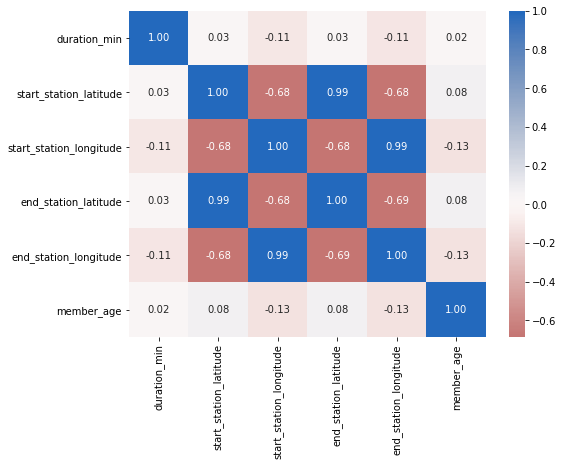

```python
# correlation plot
plt.figure(figsize=[8,6])
sns.heatmap(df[all_numeric_vars].corr(), annot=True, fmt='.2f',cmap='vlag_r', center=0 )
plt.show()
```

**`Observation:`** The correlation cofficients indicate that duration and age have very weak positive and negative correlations with the pairs of variables: (start_station_latitude, end_station_latitude) and (start_station_longitude, end_station_longitude) respectively implicating weak linear relationship. Moreover, it seems that duration and age have no linear relationship between them as their correlation value is close to 0. It would be interesting to explore the relationship between duration and age further.

**Focusing on key numeric variables (duration and age)**

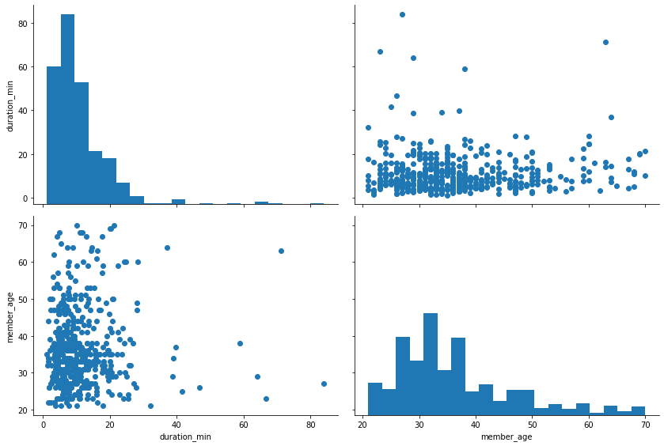

```python
# plot matrix: sample 500 records so that plots are clearer and they render faster
df_sample = df.sample(500, replace=False)
plt.figure(figsize=[8,8])
g = sns.PairGrid(data=df_sample, vars = key_numeric_vars, size=4, aspect=1.5)
g.map_offdiag(plt.scatter)
g.map_diag(plt.hist, bins=20)
plt.show()
```

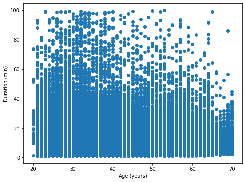

```python
# scatter plot of duration vs. member age with all the data

plt.figure(figsize=[8,6])
plt.scatter(data=df, x='member_age', y='duration_min')
plt.ylabel('Duration (min)')
plt.xlabel('Age (years)')
plt.show()
```

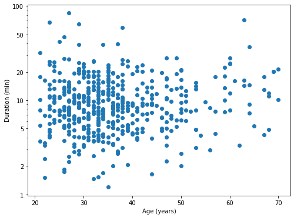

```python
# scatter plot of duration vs. member age, with sample data and log transformation on duration axis

plt.figure(figsize=[8,6])
plt.scatter(data=df_sample, x='member_age', y='duration_min')
plt.yscale('log')
plt.ylabel('Duration (min)')
plt.yticks([1,2,5,10,20,50,100],[1,2,5,10,20,50,100])
plt.xlabel('Age (years)')
plt.show()
```

**`Observation:`** Thus, after using sample data and log transformation on duration axis, it is now evident that there is no linear relationship between duration and age.

**Let's move on to looking at how duration and age correlate with the categorical variables.**

*plot matrix of numeric features (duration and age) against categorical features (dayofweek, user type, gender, bike share for all trip)*

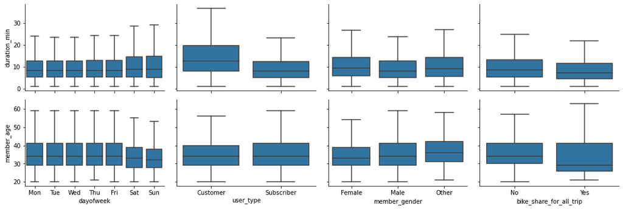

```python
def boxgrid(x, y, **kwargs):
    default_color=sns.color_palette()[0]
    sns.boxplot(x, y, color=default_color, showfliers=False) #setting showfliers = False to remove extreme values

plt.figure(figsize=[10,10])
cat_vars = ['dayofweek', 'user_type', 'member_gender', 'bike_share_for_all_trip']
g = sns.PairGrid(data=df, x_vars=cat_vars, y_vars=key_numeric_vars, size=2.5, aspect=1.5)
g.map(boxgrid)
plt.show()
```

**`Observation:`**

> - On average, bike rides on weekends (Sat-Sun) have longer durations as compared to bike rides on other weekdays (Mon-Fri).
> - on average, users who are 'Customer' have longer bike trip durations as compared to users who are 'Subscriber'.
> - On average, female bikers have longer bike trip durations as compared to male bikers.
> - On average, bikers on weekdays (Mon-Fri) are older than bikers on weekends (Sat-Sun).
> - The average age of bikers on Sunday is lower than the average age of bikers on other days.
> - The average age of 'Subscriber' and 'Customer' type bikers is approximately same.
> - The average age of male bikers is higher than that of female bikers.
> - On average, trip duration and age of bikers who did not use the bike share for their entire trip is higher as compared to those who used it for their entire trip.

*plot of numeric features (duration and age) against categorical feature time of day (hour)*

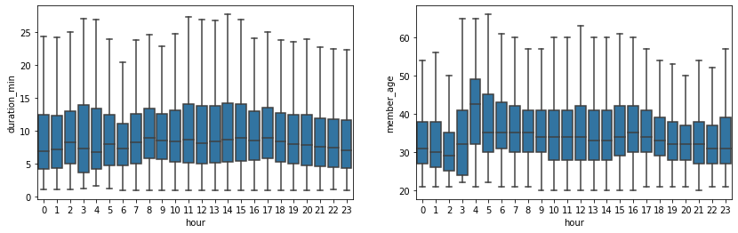

```python
fig , ax = plt.subplots(ncols=2, figsize=[14,4])
a = sns.boxplot(data=df, x='hour', y='duration_min', showfliers=False, color=default_color, ax=ax[0])
b = sns.boxplot(data=df, x='hour', y='member_age', showfliers=False, color=default_color, ax=ax[1])
plt.show()
```

**`Observation:`**

> - On average, bike rides that start between 8 AM to 6 PM have longer durations as compared to other times of the day.
> - There is no significant difference between the age of the bikers starting between 5 AM to 6 PM.
> - The average age of bikers who start at 4 AM is highest as compared to bikers who start at other time frames and interestingly it is even higher than the overall average age (34) of all the bikers. It may be because of very less number of bikers starting at this time period.
> - On average, bikers starting between 12 midnight to 3 AM have lower age as compared to other time frames

*plot the categorical variables day of week, user type, gender and bike share for all trip against duration and age again, this time with variable transformation, focusing on the entire distribution rather than average values*

```python
def log_trans(x, inverse=False):
    if not inverse:
        return np.log10(x)
    else:
        return np.power(10, x)

df['log_duration'] = df['duration_min'].apply(log_trans)
```

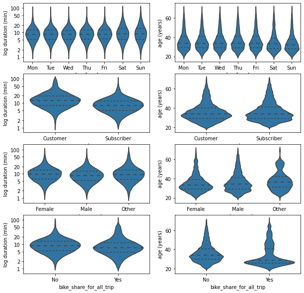

```python
fig , ax = plt.subplots(4,2, figsize=[10,10])

for i in range(len(cat_vars)):
    var = cat_vars[i]
    sns.violinplot(data=df, x=var, y='log_duration', color=default_color, inner='quartile', ax=ax[i,0])
    ax[i,0].set_yticks(log_trans(np.array([1,2,5,10,20,50,100])))
    ax[i,0].set_yticklabels([1,2,5,10,20,50,100])
    ax[i,0].set_ylabel('log duration (min)')
    sns.violinplot(data=df, x=var, y='member_age', color=default_color, inner='quartile', ax=ax[i,1])
    ax[i,1].set_ylabel('age (years)')
plt.show()
```

**`Observation:`**

- The shapes of the violins in the plots on the left side (with log duration (min) as y-axis) are more even as compared to the shapes of the violins in the plots on the right side (with age as y-axis). The transformation has made the violins on the duration variable (left side) looking more even.
- Focusing on the plot at 1st row, 1st column: There are more bike rides with durations close to the average duration time (9 minutes) on the weekdays compared to the bike rides on the weekends as the violins for former ones are wider compared to the latter ones.
- Focusing on the plot at 2nd row, 1st column: There are more bike rides with higher duration periods for users who are customers as compared to the users who are subscribers.
- Focusing on the plot at 3rd row, 1st column: There is not much difference visible in the shape of the violins for duration variable when compared to the different factors of gender (male, female) as we can see that the violins look approx. similar across these two factors.
- Focusing on the plot at 4th row, 1st column: There is slight difference in the shape of the violins when it comes to bike share for all trip variable which has more number of trips having higher bike trip durations in bike sharing for entire trip category as compared to other category which is not having bike share for the entire trip.
- There is also not much difference visible in the shape of the violins for age variable when compared to the different factors of day of week. However, subscriber user type has more number of trips involving higher age people compared to customer user type and the same goes for male users over female users.
- Also, there is slight difference in the shape of the violins when it comes to bike share for all trip variable which has more number of trips involving higher age people in bike sharing for entire trip category as compared to other category which is not having bike share for the entire trip.

*plot the categorical variable hour against duration and age again, this time with variable transformation, focusing on the entire distribution rather than average values*

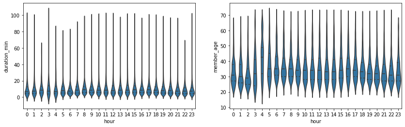

```python
fig , ax = plt.subplots(ncols=2, figsize=[14,4])
ax[0] = sns.violinplot(data=df, x='hour', y='duration_min', inner='quartile', color=default_color, ax=ax[0])
ax[1] = sns.violinplot(data=df, x='hour', y='member_age', inner='quartile', color=default_color, ax=ax[1])
plt.show()
```

- There is also not much difference visible in the shape of the violins for both the variables i.e. duration and age when compared to the different factors of hour (time of day) variable. It is because of the fact that there is too much data points to analyse the pattern clearly. Lets us take a sample.

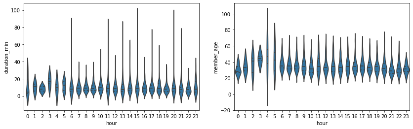

```python
df_sample2 = df.sample(2000, replace=False)
fig , ax = plt.subplots(ncols=2, figsize=[14,4])
ax[0] = sns.violinplot(data=df_sample2, x='hour', y='duration_min', inner='quartile', color=default_color, ax=ax[0])
ax[1] = sns.violinplot(data=df_sample2, x='hour', y='member_age', inner='quartile', color=default_color, ax=ax[1])
plt.show()
```

- It can be seen that after taking a sample too much noise is created in case of the violins for duration and member age variables across times of the day (hour) variable. From the above plot, it is very difficult to analyse any pattern for understanding the full distribution of age and duration variables in correlation with hour (time of the day) variable. Thus, there is a need to investigate the relationship between duration, age and time of day variables which can be explored later through multivariate exploration.

**Finally, let's look at relationships between all these categorical features.**

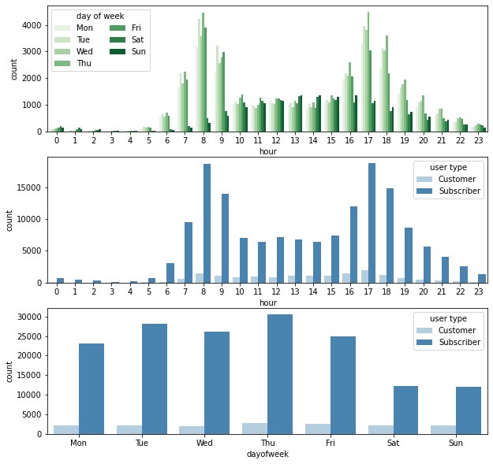

```python
# looking at key categorical features

fig, ax = plt.subplots(nrows=3, figsize=[10,10])

sns.countplot(data=df, x='hour', hue='dayofweek', palette='Greens', ax=ax[0])
ax[0].legend(title='day of week', ncol=2)
sns.countplot(data=df, x='hour', hue='user_type', palette='Blues', ax=ax[1])
ax[1].legend(title='user type')
sns.countplot(data=df, x='dayofweek', hue='user_type', palette='Blues', ax=ax[2])
ax[2].legend(title='user type')

plt.show()
```

**`Observation:`**

- Thursday, 8 AM and 5 PM has the highest bike trips across 7 days and 24 hours.
- Overall, weekdays have higher number of trips than weekends except two time frames:
  1. 10 AM - 3 PM (the usual office hours) in which both have approx. same number of trips.
  2. 12 midnight to 2 AM in which weekends have more trips than weekdays.
- Overall, Subscribers have higher number of trips than customers across all times of the day. Moreover, 8 AM and 5 PM has the most 'Subscriber' bikers compared to other hours. Also, 5 PM has the most 'Customer' bikers compared to other times of the day.
- Overall, Subscribers have higher number of trips than customers across all days of the week. Moreover, Thursday has the most 'Subscriber' and 'Customer' bikers compared to other days.

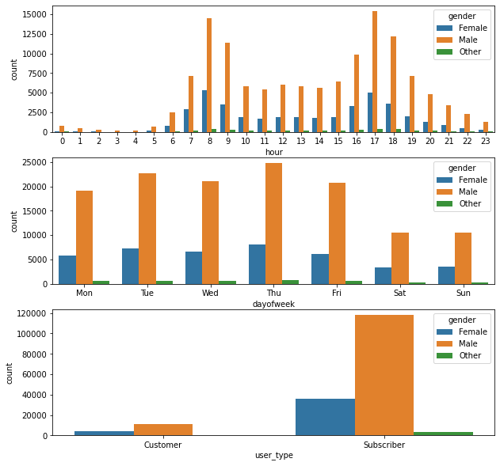

```python
# including other categorical features such as gender

fig, ax = plt.subplots(nrows=3, figsize=[10,10])

sns.countplot(data=df, x='hour', hue='member_gender', palette='tab10', ax=ax[0])
ax[0].legend(title='gender')
sns.countplot(data=df, x='dayofweek', hue='member_gender', palette='tab10', ax=ax[1])
ax[1].legend(title='gender')
sns.countplot(data=df, x='user_type', hue='member_gender', palette='tab10', ax=ax[2])
ax[2].legend(title='gender')
plt.show()
```

**`Observation:`**

> - Overall, male bikers have higher number of trips as compared to female and other gender type across all the times of the day (hour) and days of the week.
> - Most of the Subscriber bikers are male. Most of the Customer bikers are also male.
> - 8 AM and 5 PM has the highest male and female bikers across 24 hours
> - Thursday has the most male bikers compared to other days. It also has the most female bikers compared to other days.

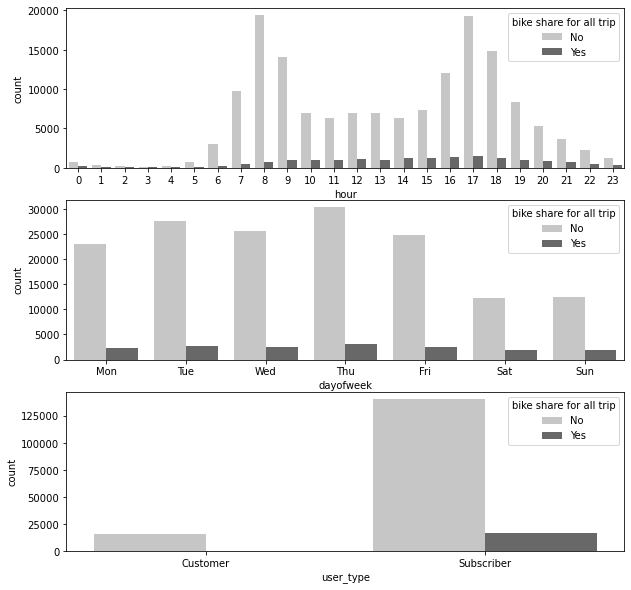

```python
# including other categorical features such as bike share for all trip

fig, ax = plt.subplots(nrows=3, figsize=[10,10])

sns.countplot(data=df, x='hour', hue='bike_share_for_all_trip', palette='Greys', ax=ax[0])
ax[0].legend(title='bike share for all trip')
sns.countplot(data=df, x='dayofweek', hue='bike_share_for_all_trip', palette='Greys', ax=ax[1])
ax[1].legend(title='bike share for all trip')
sns.countplot(data=df, x='user_type', hue='bike_share_for_all_trip', palette='Greys', ax=ax[2])
ax[2].legend(title='bike share for all trip')
plt.show()
```

**`Observation:`**

> - Overall, bikers who do not use bike share for their entire trip have higher number of trips across all times of the day and days of the week as compared to those who do.
> - Out of all the customer bikers, all of them have not used bike share for their entire trip whereas in case of subscribers, a very small proportion of them have used bike share for their entire trip.

### Talk about some of the relationships you observed in this part of the investigation. How did the feature(s) of interest vary with other features in the dataset?

> - After using sample data and log transformation on duration axis, it was evident that there is no linear relationship between duration and age.
> - On average, bike rides on weekends (Sat-Sun) have longer durations as compared to bike rides on other weekdays (Mon-Fri).
> - On average, users who are 'Customer' have longer bike trip durations as compared to users who are 'Subscriber'.
> - On average, female bikers have longer bike trip durations as compared to male bikers.
> - On average, bikers on weekdays (Mon-Fri) are older than bikers on weekends (Sat-Sun).
> - The average age of bikers on Sunday is lower than the average age of bikers on other days.
> - The average age of 'Subscriber' and 'Customer' type bikers is approximately same.
> - The average age of male bikers is higher than that of female bikers.
> - On average, bike rides that start between 8 AM to 6 PM have longer durations as compared to other times of the day.
> - There is no significant difference between the age of the bikers starting between 5 AM to 6 PM.
> - The average age of bikers who start at 4 AM is highest as compared to bikers who start at other time frames and interestingly it is even higher than the overall average age (34) of all the bikers. It may be because of very less number of bikers starting at this time period.
> - On average, bikers starting between 12 midnight to 3 AM have lower age as compared to other time frames.
> - There are more bike rides with durations close to the average duration time (9 minutes) on the weekdays compared to the bike rides on the weekends.
> - There are more bike rides with higher duration periods for users who are customers as compared to the users who are subscribers.
> - There was not much difference visible in the distribution of duration variable across male and female bikers implicating that higher average bike trip duration of female bikers was because of them being less in number as compared to male bikers.
> - There was also not much difference visible in the distribution of age variable across days of the week. However, subscriber user type has more older people compared to customer user type and the same goes for male users over female users.
> - Thursday, 8 AM and 5 PM has the highest bike trips across 7 days and 24 hours.
> - Overall, weekdays have higher number of trips than weekends except two time frames:
>   1. 10 AM - 3 PM (the usual office hours) in which both have approx. same number of trips.
>   2. 12 midnight to 2 AM in which weekends have more trips than weekdays.
> - Overall, Subscribers have higher number of trips than customers across all times of the day. Moreover, 8 AM and 5 PM has the most 'Subscriber' bikers compared to other hours. Also, 5 PM has the most 'Customer' bikers compared to other times of the day.
> - Overall, Subscribers have higher number of trips than customers across all days of the week. Moreover, Thursday has the most 'Subscriber' and 'Customer' bikers compared to other days.
> - Overall, male bikers have higher number of trips as compared to female and other gender type across all the times of the day (hour) and days of the week.
> - Most of the Subscriber bikers are male. Most of the Customer bikers are also male.
> - 8 AM and 5 PM has the highest male and female bikers across 24 hours
> - Thursday has the most male bikers compared to other days. It also has the most female bikers compared to other days.

### Did you observe any interesting relationships between the other features (not the main feature(s) of interest)?

> - On average, trip duration and age of bikers who did not use the bike share for their entire trip is higher as compared to those who used it for their entire trip.

However, interestingly:

> - The trips involving bike sharing for entire trip have more number of long bike trip durations than those who do not have bike share for the entire trip.
> - The trips involving bike sharing for entire trip have more older people than those who do not have bike share for the entire trip.

implicating that higher average trip duration and age of bikers for those who did not use the bike share for their entire trip was a result of majority of the users having not used bike share for their entire trip.

> - Overall, bikers who do not use bike share for their entire trip have higher number of trips across all times of the day and days of the week as compared to those who do.
> - Out of all the customer bikers, all of them have not used bike share for their entire trip whereas in case of subscribers, a very small proportion of them have used bike share for their entire trip.

## Multivariate Exploration

**Comparing the categorical features based on mean bike trip duration**

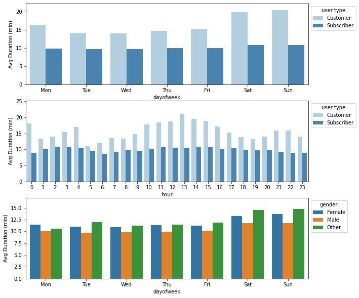

```python
# comparing the categorical features based on mean duration

fig, ax = plt.subplots(nrows=3, figsize=[10,10])

sns.barplot(data=df, x='dayofweek', y='duration_min', hue='user_type', palette='Blues', errwidth=0, ax=ax[0])
ax[0].set_ylabel('Avg Duration (min)')
ax[0].legend(loc=2, title='user type', bbox_to_anchor=(1,1))
sns.barplot(data=df, x='hour', y='duration_min', hue='user_type', palette='Blues', errwidth=0, ax=ax[1])
ax[1].set_ylabel('Avg Duration (min)')
ax[1].legend(loc=2, title='user type', bbox_to_anchor=(1,1))
sns.barplot(data=df, x='dayofweek', y='duration_min', hue='member_gender', palette='tab10', errwidth=0, ax=ax[2])
ax[2].set_ylabel('Avg Duration (min)')
ax[2].legend(loc=2, title='gender', bbox_to_anchor=(1,1))
plt.show()
```

**`Observation:`**

> - Customers have higher average bike trip duration than subscribers across all the times of the day (hour) and days of the week with customers having higher average bike trip duration on weekends (Sat-Sun) as compared to weekdays (Mon-Fri) and same goes for subsribers.
> - Female bikers have higher average bike trip duration than male bikers across all the days of the week with female bikers having higher average bike trip duration on weekends (Sat-Sun) as compared to weekdays (Mon-Fri) and same goes for male bikers.

**The main thing I want to explore now is how the four categorical measures i.e. hour, day of week, user type and gender play into the relationship between duration and age.**

```python
df.log_duration.describe()
```

```
count    173401.000000
mean          0.924317
std           0.291292
min           0.007179
25%           0.731051
50%           0.928567
75%           1.116165
max           1.998985
Name: log_duration, dtype: float64
```

```python
def hist2dgrid(x, y, **kwargs):
    palette=kwargs.pop('color')
    bins_x =np.arange(18, df.member_age.max()+2, 2)
    bins_y =np.arange(0, 2+0.1, 0.1)
    plt.hist2d(x, y, bins=[bins_x,bins_y], cmap=palette, cmin=0.5)
    plt.yticks(log_trans(np.array([1,2,5,10,20,50,100])),[1,2,5,10,20,50,100])
```

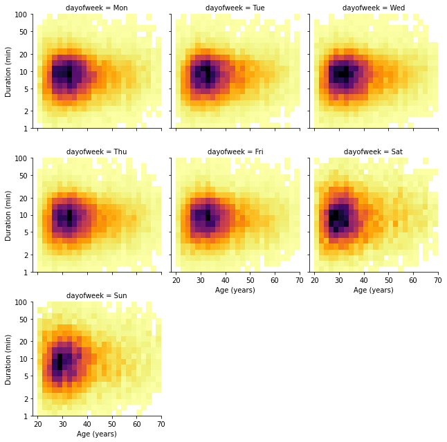

```python
g = sns.FacetGrid(data = df, col = 'dayofweek', col_wrap=3, size=3)
g.map(hist2dgrid, 'member_age', 'log_duration', color='inferno_r')
g.set_xlabels('Age (years)')
g.set_ylabels('Duration (min)')
plt.show();
```

**`Observation:`**

> - From the above we can see the relationship of days of the week against duration and age, the cloud of points is wide and shorter in length on weekdays implicating that more trips are taken by older people and are shorter in duration during this period and it becomes narrow and higher in length on weekends implicating that more trips are taken by younger people and are longer in duration during this period.

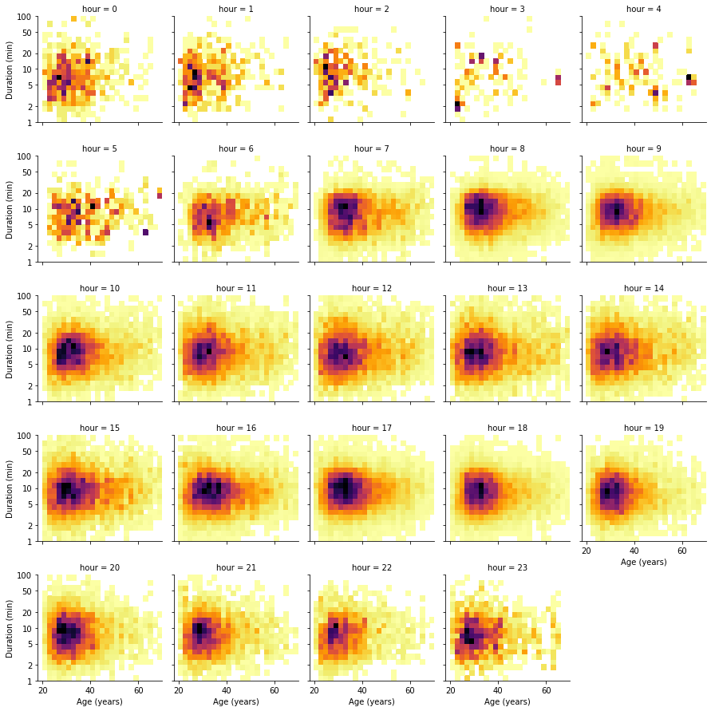

```python
g = sns.FacetGrid(data = df, col = 'hour', col_wrap=5, size=2.5)
g.map(hist2dgrid, 'member_age', 'log_duration', color='inferno_r')
g.set_xlabels('Age (years)')
g.set_ylabels('Duration (min)')
plt.show()
```

**`Observation:`**

> - From 12 midnight till 5 AM, we can not see the relationship of hour (time of the day) against duration and age. But from 6 AM to 10 AM, the cloud of points is wide and shorter in length implicating that more trips are taken by older people and are shorter in duration and the pattern is repeated from 4 PM - 6 PM. Whereas, from 11 AM - 3 PM, the cloud of points is narrow and higher in length implicating that more trips are taken by younger people and are longer in duration and this pattern is also repeated from 7 PM - 11 PM.

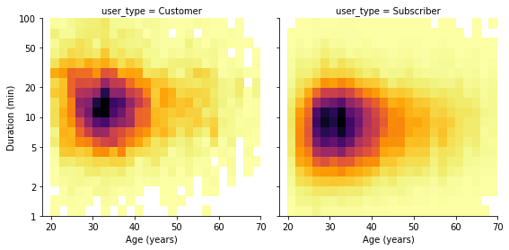

```python
g = sns.FacetGrid(data = df, col = 'user_type', size=4)
g.map(hist2dgrid, 'member_age', 'log_duration', color='inferno_r')
g.set_xlabels('Age (years)')
g.set_ylabels('Duration (min)')
plt.show();
```

**`Observation:`**

> - From the above we can see the relationship of user type against duration and age, the cloud of points is wide and shorter in length in case of subscribers implicating that more trips are taken by older people and are shorter in duration for this user type and it becomes narrow and higher in length in case of customers implicating that more trips are taken by younger people and are longer in duration for this user type.

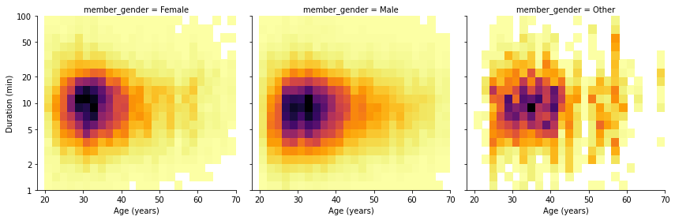

```python
g = sns.FacetGrid(data = df, col = 'member_gender', size=4)
g.map(hist2dgrid, 'member_age', 'log_duration', color='inferno_r')
g.set_xlabels('Age (years)')
g.set_ylabels('Duration (min)')
plt.show();
```

**`Observation:`**

> - From the above we can see the relationship of gender type against duration and age, the cloud of points is wide and shorter in length in case of males implicating that more trips are taken by older people and are shorter in duration for males and it becomes narrow and higher in length in case of females implicating that more trips are taken by younger people and are longer in duration for females.

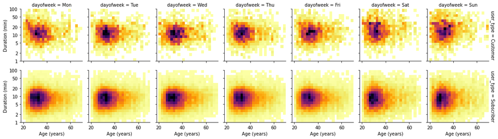

```python
# create faceted heat maps on levels of day of week and user type
g = sns.FacetGrid(data = df, row = 'user_type', col='dayofweek', size=2.25, margin_titles=True)
g.map(hist2dgrid, 'member_age', 'log_duration', color='inferno_r')
g.set_xlabels('Age (years)')
g.set_ylabels('Duration (min)')
plt.show()
```

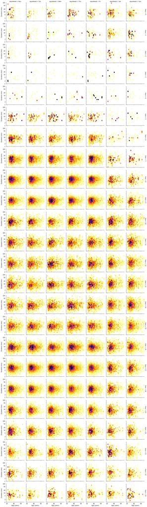

```python
# create faceted heat maps on levels of hour and day of week
g = sns.FacetGrid(data = df, row = 'hour', col='dayofweek', size=2.25, margin_titles=True)
g.map(hist2dgrid, 'member_age', 'log_duration', color='inferno_r')
g.set_xlabels('Age (years)')
g.set_ylabels('Duration (min)')
plt.show()
```

I tried looking at faceted heat maps across the levels of hour, day of week and user type variables together, but it seems like there's too many facets to look at. Perhaps a better summary can come from dividing the age into two groups and focus on each group.

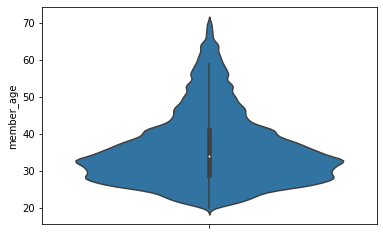

```python
sns.violinplot(data=df, y='member_age');
```

Based on the above plot, we can divide the age into two categories i.e. middle aged adults (20-40) and adults (>40)

```python
middle_adults = df[df['member_age'] <= 40]
adults = df[df['member_age'] > 40]
```

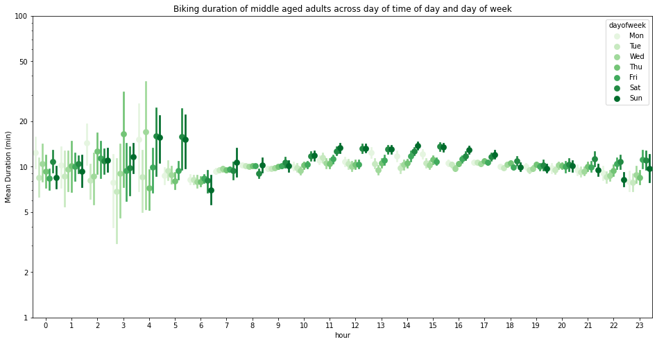

```python
fig = plt.figure(figsize=[16,8])
ax = sns.pointplot(data=middle_adults, x='hour', y='duration_min', hue='dayofweek', linestyles="", palette='Greens', dodge=0.8)
plt.title('Biking duration of middle aged adults across day of time of day and day of week')
plt.ylabel('Mean Duration (min)')
plt.yscale('log')
plt.yticks([1,2,5,10,20,50,100],[1,2,5,10,20,50,100])
ax.set_yticklabels([],minor = True)
plt.show()
```

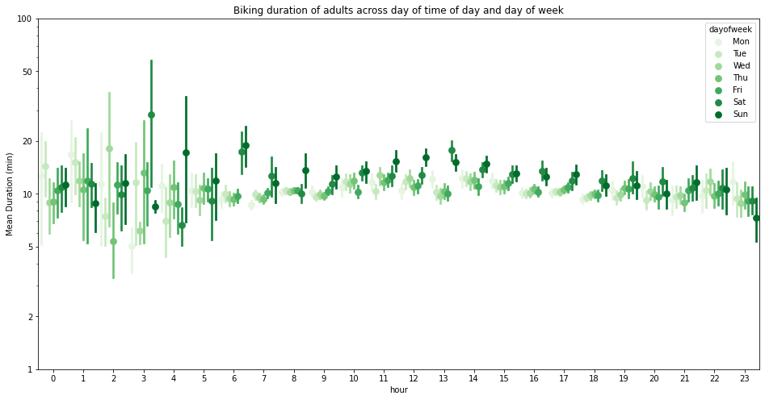

```python
fig = plt.figure(figsize=[16,8])
ax = sns.pointplot(data=adults, x='hour', y='duration_min', hue='dayofweek', linestyles="", palette='Greens', dodge=0.8)
plt.title('Biking duration of adults across day of time of day and day of week')
plt.ylabel('Mean Duration (min)')
plt.yscale('log')
plt.yticks([1,2,5,10,20,50,100],[1,2,5,10,20,50,100])
ax.set_yticklabels([],minor = True)
plt.show()
```

**`Observation:`**

> - By looking at the errorbars in both pointplots, we can tell that there are more middle aged bikers (age <= 40) across 7 days and 24 hours.
> - Middle aged adult bikers bike for longer periods from 10 AM - 5 PM on weekends (Sat-Sun) as compared to weekdays (Mon-Fri).
> - Whereas adult bikers bike for longer periods from 6 AM - 6 PM on weekends (Sat-Sun) as compared to weekdays (Mon-Fri).

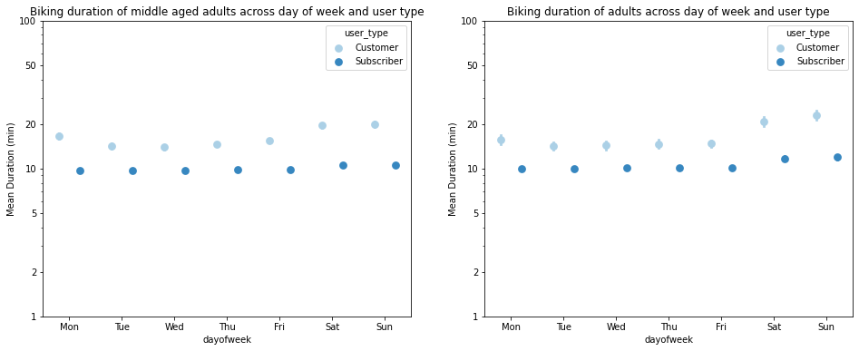

```python
fig, ax = plt.subplots(ncols=2, figsize=[16,6])

sns.pointplot(data=middle_adults, x='dayofweek', y='duration_min', hue='user_type', linestyles="", palette='Blues', dodge=0.4,
              ax=ax[0])
ax[0].set_title('Biking duration of middle aged adults across day of week and user type')
ax[0].set_ylabel('Mean Duration (min)')
ax[0].set_yscale('log')
ax[0].set_yticks([1,2,5,10,20,50,100])
ax[0].set_yticklabels([1,2,5,10,20,50,100])
ax[0].set_yticklabels([],minor = True)

sns.pointplot(data=adults, x='dayofweek', y='duration_min', hue='user_type', linestyles="", palette='Blues', dodge=0.4, \
                  ax=ax[1])
ax[1].set_title('Biking duration of adults across day of week and user type')
ax[1].set_ylabel('Mean Duration (min)')
ax[1].set_yscale('log')
ax[1].set_yticks([1,2,5,10,20,50,100])
ax[1].set_yticklabels([1,2,5,10,20,50,100])
ax[1].set_yticklabels([],minor = True)
plt.show()
```

**`Observation:`**

> - By looking at the errorbars in both pointplots, we can tell that there are more middle aged bikers.
> - 'Customer' bikers bike longer than 'Subscriber' bikers for both middle aged adults (less than 40 years) and adults (more than 40 years).
> - Additionally, 'Customer' bikers bike longer on weekends as compared to weekdays for both middle aged adults and adults whereas the difference between weekdays and weekends in terms of biking duration is insignificant in case of middle aged subscribers.

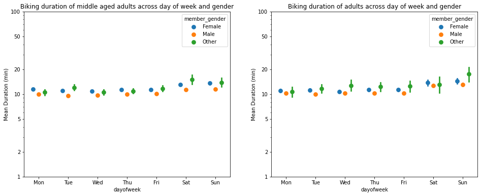

```python
fig, ax = plt.subplots(ncols=2, figsize=[16,6])

sns.pointplot(data=middle_adults, x='dayofweek', y='duration_min', hue='member_gender', linestyles="", palette='tab10', \
              dodge=0.4, ax=ax[0])
ax[0].set_title('Biking duration of middle aged adults across day of week and gender')
ax[0].set_ylabel('Mean Duration (min)')
ax[0].set_yscale('log')
ax[0].set_yticks([1,2,5,10,20,50,100])
ax[0].set_yticklabels([1,2,5,10,20,50,100])
ax[0].set_yticklabels([],minor = True)

sns.pointplot(data=adults, x='dayofweek', y='duration_min', hue='member_gender', linestyles="", palette='tab10', dodge=0.4, \
                  ax=ax[1])
ax[1].set_title('Biking duration of adults across day of week and gender')
ax[1].set_ylabel('Mean Duration (min)')
ax[1].set_yscale('log')
ax[1].set_yticks([1,2,5,10,20,50,100])
ax[1].set_yticklabels([1,2,5,10,20,50,100])
ax[1].set_yticklabels([],minor = True)
plt.show()
```

**`Observation:`**

> - By looking at the height of errorbars in both the pointplots, we can tell that there are less bikers who are older than 40 years old.
> - Female bikers bike longer than male bikers and the biking pattern i.e. average biking duration across all the days of the week is same for both middle aged adults and adults in case of female and male bikers.

**Plotting all the three key categorical variables (user type, time of the day and days of the week) together**

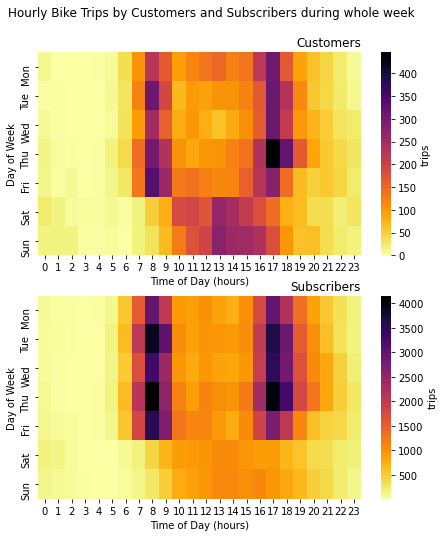

```python
fig, ax = plt.subplots(nrows=2, figsize=[8,8])

fig.suptitle('Hourly Bike Trips by Customers and Subscribers during whole week')

customers = df.query('user_type == "Customer"')
ct_counts = customers.groupby(['dayofweek', 'hour']).size()
ct_counts = ct_counts.reset_index(name='trips')
ct_counts = ct_counts.pivot(index='dayofweek', columns=['hour'], values='trips')
sns.heatmap(data=ct_counts, fmt='.0f',cmap='inferno_r', cbar_kws={'label':'trips'}, ax=ax[0])
ax[0].set_title('Customers', loc='right')
ax[0].set_xlabel('Time of Day (hours)')
ax[0].set_ylabel('Day of Week')


subscribers = df.query('user_type == "Subscriber"')
sb_counts = subscribers.groupby(['dayofweek', 'hour']).size()
sb_counts = sb_counts.reset_index(name='trips')
sb_counts = sb_counts.pivot(index='dayofweek', columns=['hour'], values='trips')
sns.heatmap(data=sb_counts, fmt='.0f', cmap='inferno_r', cbar_kws={'label':'trips'}, ax=ax[1])
ax[1].set_title('Subscribers', loc='right')
ax[1].set_xlabel('Time of Day (hours)')
ax[1].set_ylabel('Day of Week')
#adjusting figure main title
fig.subplots_adjust(top =0.90, left=0.20)
plt.show()
```

**`Observation:`** The heatmaps show clearly a very different usage pattern between the two type of bike riders. Subscribers use the bike sharing system heavily on work days i.e. Monday through Friday whereas customers ride a lot on weekends i.e. Saturday and Sunday, especially in the afternoon. Many trips are concentrated around 8-9 AM and 4-6 PM on work days for subscribers who probably use the system for work commute, yet customers tend to use more in the late afternoon around 5 PM on weekdays (Monday to Friday). Other than usage purpose and habit, traffic situation around these rush hours in the area may also have an influence in this trend.

### Talk about some of the relationships you observed in this part of the investigation. Were there features that strengthened each other in terms of looking at your feature(s) of interest?

The multivariate exploration strengthened some of the patterns discovered in the previous bivariate exploration as well as univariate exploration, the relationship between multiple categorical variables (user type, gender, time of the day, day of the week), effect of various levels of each categorical variable on the relationship between duration and age are visualized altogether and observations were noted. The efficient/short period of usage for subscribers, involving more older people as compared to customer bikers, corresponds to their high concentration on rush hours Monday through Friday, indicating that they use the system heavily on weekdays, compared to customer bikers, primarily for work commute. Whereas, customer bikers who have more younger people as compared to the subscribers have more relaxing and flexible usage pattern. It is supported by the fact that they're taking advantage of the bike sharing system quite differently from the subscribers as they use the system heavily on weekends (especially in the afternoon) compared to subscribers for city tour or leisure purpose probably.

However, a very little distinguishing pattern of biking duration of was observed when we compared the biking duration of middle aged adults and adults for all days of the week across different times of the day as both middle aged adults and adults bike for longer periods in approx. same time frames on weekends (Sat-Sun) as compared to weekdays (Mon-Fri):

1. 10 AM - 5 PM on weekends for middle aged adults
2. 6 AM - 6 PM on weekends for adults

Also, no distinguishing pattern of biking duration was observed among middle aged adults and adults for all days of the week across gender types which might be a result of very less female biker data as compared to male bikers.

### Were there any interesting or surprising interactions between features?

The interactions between features were all supplementing each other and made sense when looked altogether. Hence, there was no big surprising observation. The usage habit difference between male/female and bike share for all trip (yes/no) was not significant or we can say obvious throughout the exploration, which could be related to the imbalanced number of female riders compared to male ones. It would be interesting to see how male and female use the system differently if there were more female data and the same can be said for bike sharing for all trip feature.

## References

- [Retrieving hour, day and month from date in python](https://docs.python.org/2/library/datetime.html#strftime-strptime-behavior)
- [Handling missing data](https://blogs.oracle.com/datascience/3-methods-to-handle-missing-data)
- [Age from birth year in python](https://stackoverflow.com/questions/2217488/age-from-birthdate-in-python)